# How Changes in Tree Cover in the Amazon Rain Forest correlate with a Change in Terrestrial Water Storage

Moritz Weber

18 Dezember 2025

```r
library(here)
```

## Introduction

The Amazon rain forest plays a vital role in the earth’s climate system and global water cycle. It acts as a big carbon sink and contributes significantly to regional and global precipitation patterns through evapotranspiration. However, widespread deforestation driven by agriculture, logging, and urbanization threaten the Amazon rain forest. Changes in forest cover can disrupt water storage and availability, affecting surface water, soil moisture, and groundwater dynamics. By analyzing terrestrial water storage anomalies from GRACE/GRACE-FO data in relation to deforestation areas, I want to see if there is a quantifiable correlation between the two. In order to get a most complete picture of the situation, a relatively large area of interest is chosen:

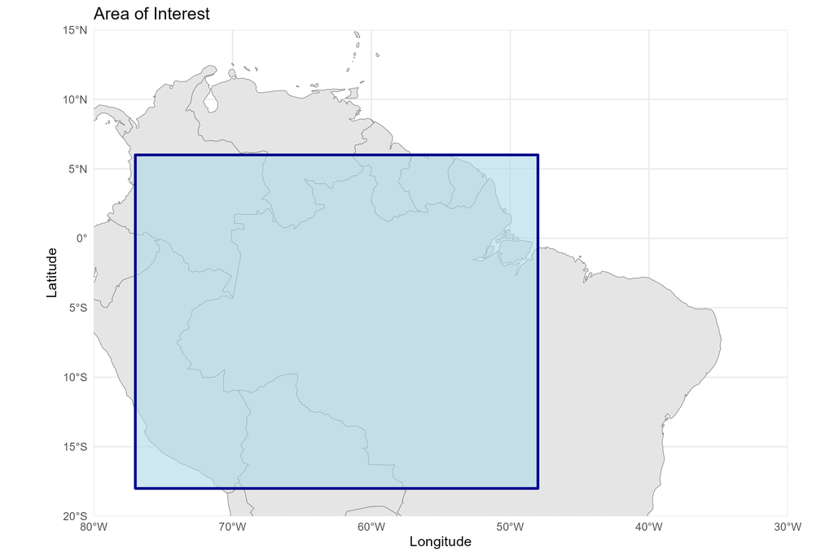

```r
knitr::include_graphics(
  here("fig", "area_of_interest.png")
)
```

## Methods and Data

There are two data sets being used for this project, the first one being “COST-G GravIS RL02 Terrestrial Water Storage Anomalies”. The GRACE-FO satellites, which have been in orbit since 2002, gather data about earth’s gravitational anomalies. In this specific data set, the collected data is processed to terrestrial water storage anomalies relative to the long term mean of April 2002 - March 2020, provided in cm of equivalent water height at a rather big pixel size of 1° latitude/longitude and a monthly temporal resolution.

The second data set is the tree cover product, provided by MODIS/Terra Vegetation. Its pixel size is very small with 250 by 250 meters and it has a yearly temporal resolution.

The aim of this project is to relate the change in the yearly amplitude of terrestrial water storage anomaly for the longest possible period, April 2002 - May 2025, to the change in tree cover from the measuring period March 2000 - March 2001 to the measuring period March 2024 - March 2025. The hypothesis which is being researched is as follows: for areas with declined tree cover, the trend in the amplitude of TWS storage will decline, as there is less vegetation surface for evapotranspiration to take place, lowering the maximum water storage - similar to the well known principle of “Schwammstadt” in urban geography.

The first part of data processing handles the GRACE-FO data on terrestrial water storage. The monthly data is grouped by years, the cut-off date being July 1st (for a clear yearly amplitude), and the yearly amplitude extracted. Now, with this time series of yearly TWS amplitudes for the period April 2002 - May 2025, for every spatial data point a linear regression is made to calculate the trend of TWS for said period. The result is a raster showing the yearly change in TWS in centimeter water height equivalent.

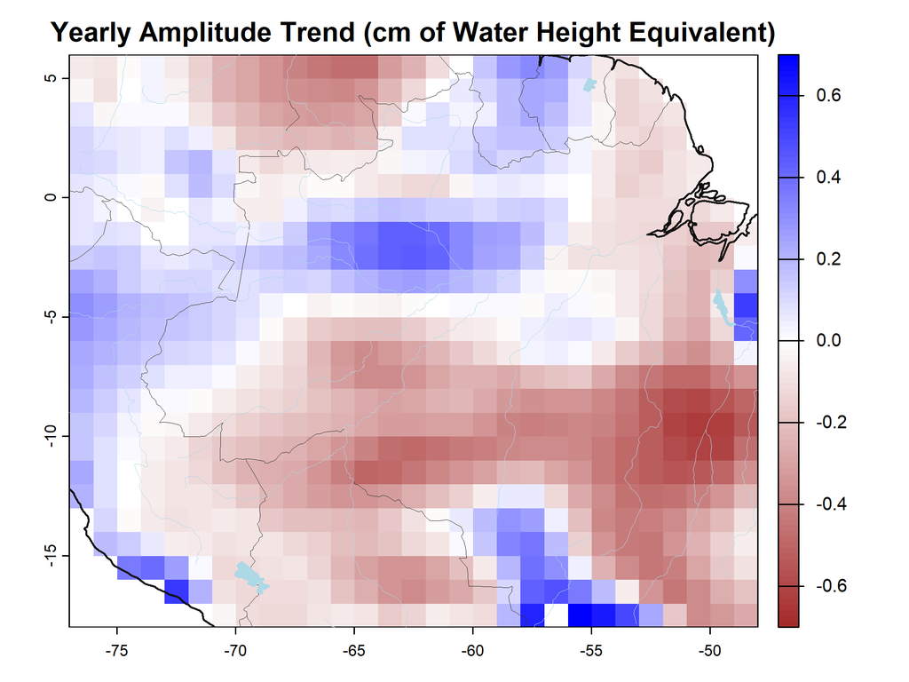

```r
knitr::include_graphics(
  here("fig", "trend_amplitude_tws.png")
)
```

The second part of data processing concerns the change in tree cover. From the downloaded .hdf files, which include multiple layers with vegetation related data, the layers containing the tree cover data need to be extracted, mosaiced together and then masked with the area of interest, which results in two rasters displaying the amount of tree covered area in percent for the periods of March 2000 - March 2001 and March 2024 - March 2025.

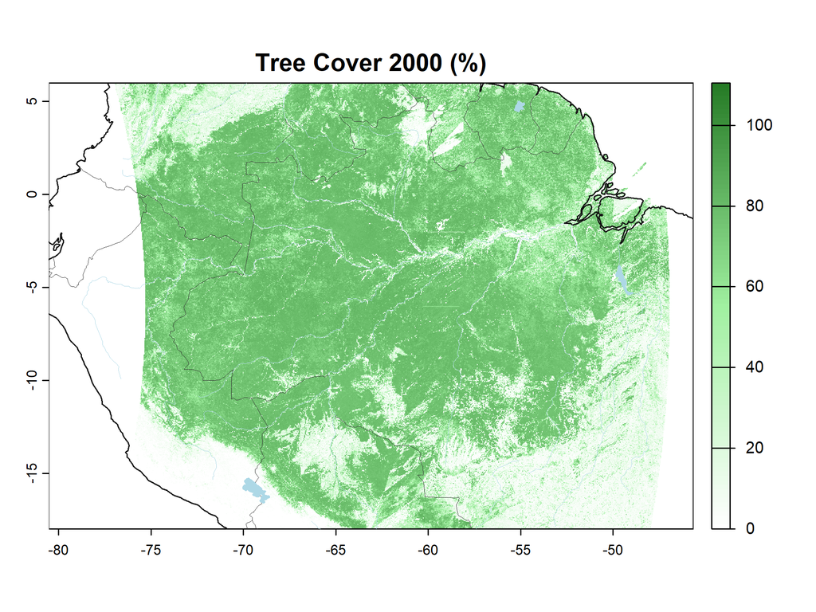

```r
knitr::include_graphics(
  here("fig", "tree_cover_2000.png")
)
```

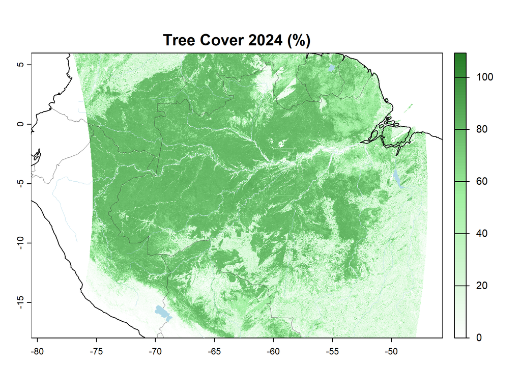

```r
knitr::include_graphics(
  here("fig", "tree_cover_2024.png")
)
```

For further data processing and better visual understanding, the two rasters are subtracted from one another, resulting in the change in tree cover over the 24 year period, displayed in percent.

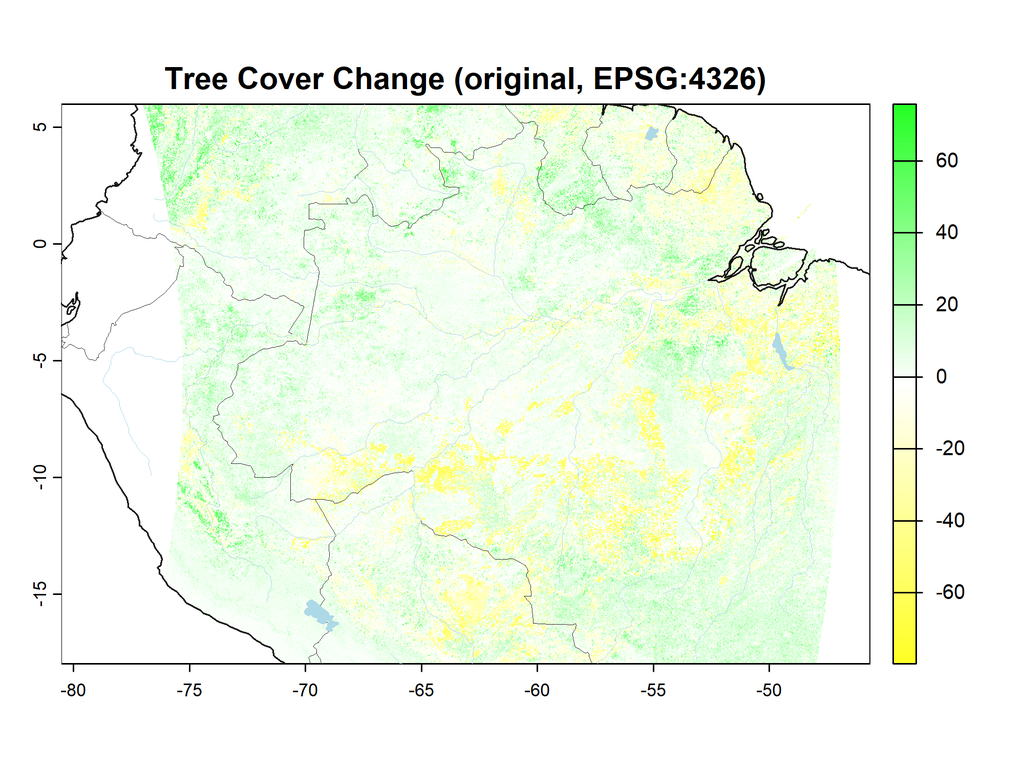

```r
knitr::include_graphics(
  here("fig", "tree_cover_change_original_deg.png")
)
```

For statistical analysis, the tree cover change raster’s spatial resolution needs to be adapted to the much lower spatial resolution of the TWS raster, which looks as follows:

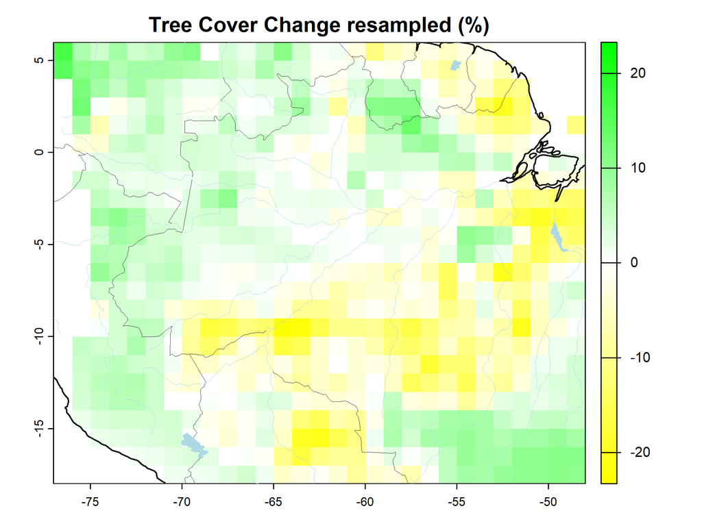

```r
knitr::include_graphics(
  here("fig", "tree_cover_change_resampled.png")
)
```

## Results

For statistical analysis a simple linear regression was chosen. It relates the average yearly change in terrestrial water storage over a 23 year period to the absolute change in tree covered area which happened over a period of 24 years.

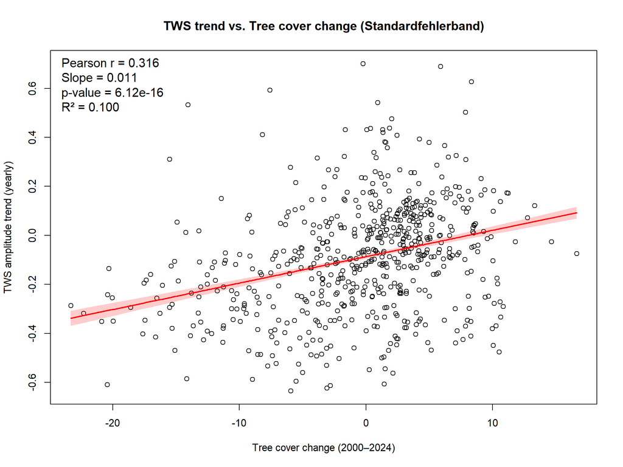

```r
knitr::include_graphics(
  here("fig", "scatter_trend_vs_treecover_SEband.png")
)
```

This result poses a further question: If the amplitude of TWS does indeed follow a negative trend for areas with decreased tree cover, is it because the highest values decrease, the lowest values increase, or both? In order to figure this out, the same process as before is applied - but now with the yearly maximum and the yearly minimum value of TWS, which results in a two rasters showing the trend of said minimum and maximum values.

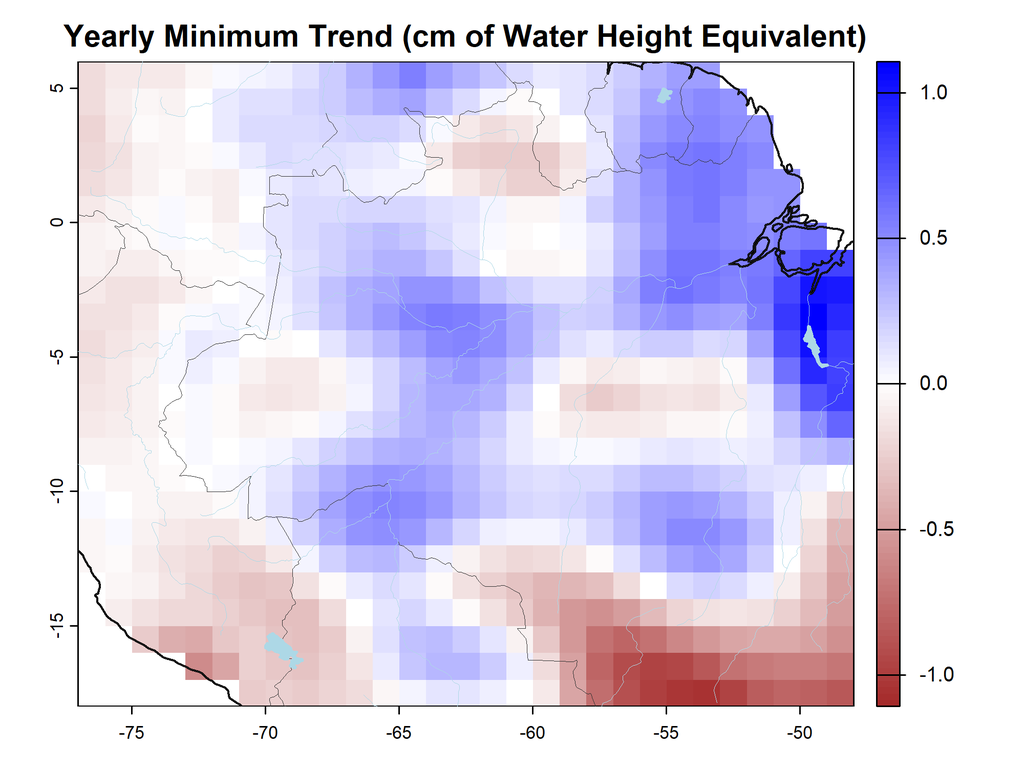

```r
knitr::include_graphics(
  here("fig", "min_trend_tws.png")
)
```

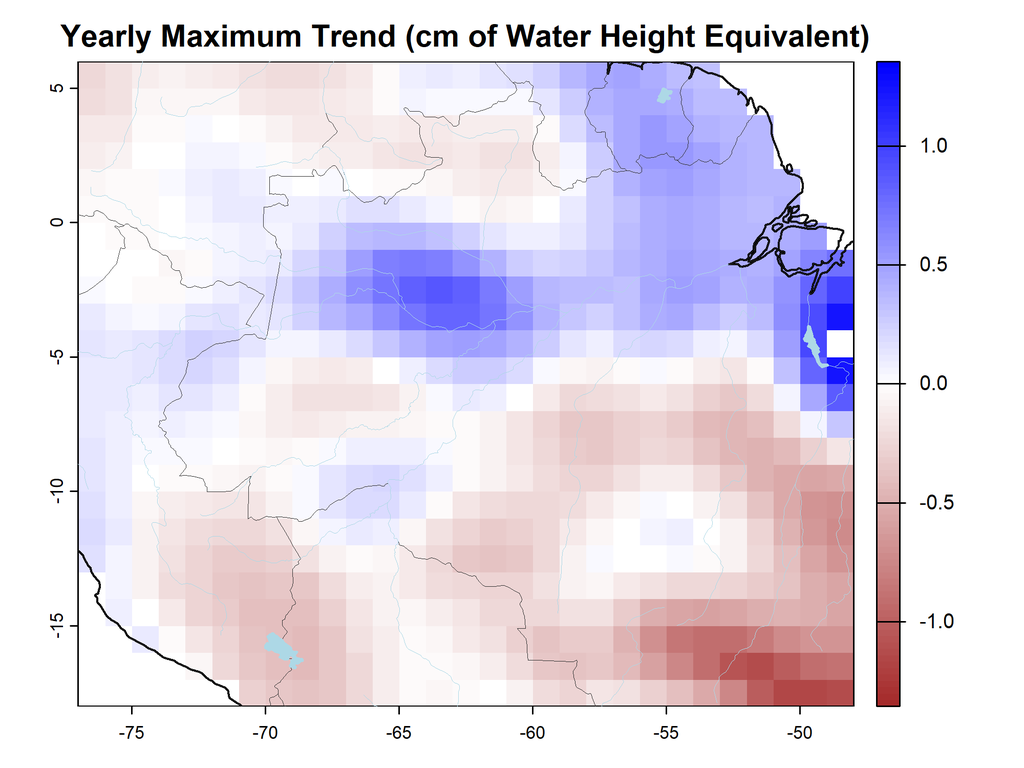

```r
knitr::include_graphics(
  here("fig", "max_trend_tws.png")
)
```

Now, the same statistical analysis is carried out.

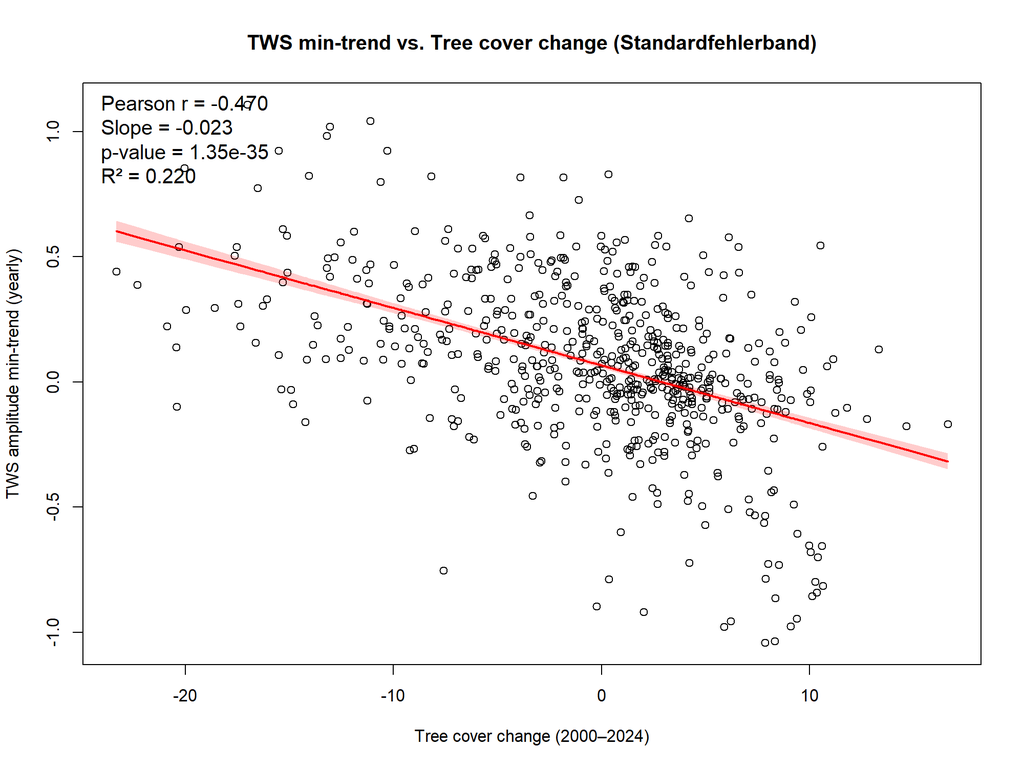

```r
knitr::include_graphics(
  here("fig", "scatter_mintrend_vs_treecover_SEband.png")
)
```

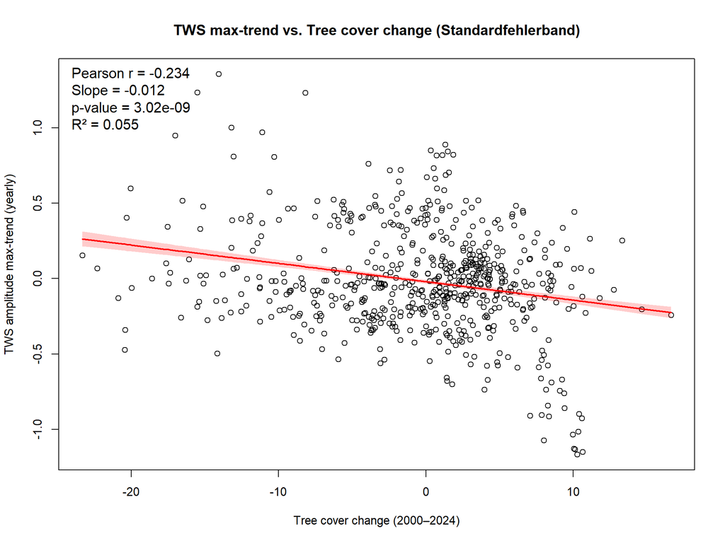

```r
knitr::include_graphics(
  here("fig", "scatter_maxtrend_vs_treecover_SEband.png")
)
```

## Discusion

The results show a clear connection between long-term changes in tree cover and changes in terrestrial water storage, but the relationship is weaker and more complex than initially expected. The observed positive correlation between tree cover loss and a declining TWS amplitude supports the basic hypothesis that deforestation reduces the capacity of the land surface to store and release water. However, the explanatory power of the model remains relatively small. This suggests that tree cover is only one of several factors influencing the variability and long-term development of TWS in the Amazon region.

The additional analysis of minimum and maximum TWS values helps to clarify the mechanisms behind the declining amplitude. While both extremes show an i ncreasing trend in areas with reduced tree cover, the increase in minimum values is quite a lot stronger. This implies that the ecosystem is changing to a state of weaker drought periods, where the minimal amount of water stored is higher than before. One possible explanation is that deforested areas experience less evapotranspiration, which reduces the drawdown of water during the dry season and therefore increases the minimum values. At the same time, the smaller increase in maximum values indicates that peak water storage is also suppressed, although not as strongly, which could be attributed to less leaf area, leading to less transpiration, and ultimately to less water storage.

These results fit with earlier findings that link forest loss to reduced atmospheric moisture recycling and altered seasonal water dynamics. However, most studies emphasize reduced precipitation and drying trends (Vergopolan & Fisher 2016; Lima et al. 2014). The pattern observed here — rising minimum storage — highlights a different aspect of the hydrological response. It suggests that not only atmospheric processes but also land-surface processes, such as soil infiltration, root depth, and runoff generation, contribute to the changing TWS dynamics.

Several limitations of this project need to be considered. First, the spatial resolution mismatch between the GRACE-FO data and the MODIS tree cover product means that small-scale features of deforestation are inevitably averaged out. Furthermore, as shown by Cassiano et al. in 2006, the resolution of a remote sensing study is crucial when looking at deforestation and hydrological processes, a coarse resolution can strongly dilute the received signal and fails to incorporate spatial heterogenity and mesoscale patterns. Second, the TWS trends combine many hydrological components — soil moisture, surface water, groundwater — and cannot be attributed to vegetation change alone. Climate oscillations, dam construction, groundwater extraction, and long-term precipitation trends likely influence the signal as well. Third, tree cover may be a relevant indicator for vegetation changes related to deforestation, but it misses multiple variables, such as leaf area index or changes happening in smaller cycles (for example an area which was cleared up, used agriculturally for a period of time and then reforested).

Despite these limitations, the analysis gives a consistent picture: areas with stronger tree cover loss tend to shift toward a reduced TWS amplitude, driven mainly by a rise in minimum water storage. This suggests that deforestation modifies not only the quantity of stored water but also the seasonal dynamics of how water moves through the system. In a region as sensitive as the Amazon, such long-term shifts are relevant for understanding changing flood and drought regimes, the resilience of the ecosystem, and the feedbacks between land cover and climate.

## References

D’Almeida, C. et al. (2006) “Spatial Distribution of the Hydrological Impact of Deforestation in Amazonia.”

Lima, Letícia S. et al. (2014) “Feedbacks between deforestation, climate, and hydrology in the Southwestern Amazon: implications for the provision of ecosystem services,” Landscape Ecology, 29(2), pp. 261–274. Available at: https://doi.org/10.1007/s10980-013-9962-1.

Vergopolan, N. and Fisher, J.B. (2016) “The impact of deforestation on the hydrological cycle in Amazonia as observed from remote sensing,” International Journal of Remote Sensing, 37(22), pp. 5412–5430. Available at: https://doi.org/10.1080/01431161.2016.1232874.